# Statistics Homework 06

B08705034 施芊羽 資管二

## Chapter 7

```python
import seaborn as sns
import pandas as pd
import numpy as np
import scipy.stats as stats
import statsmodels.api as sm
import statsmodels.stats.api as sms
import statsmodels.formula.api as smf
import math as math
import statistics
from matplotlib import pyplot as plt
%matplotlib inline
from numpy import random
from scipy.stats import binom
plt.rcParams["figure.dpi"] = 100
```

### 7.13

#### a.

Suppose $P(n)$ represents the probability of a university graduate is offered $n$ job(s) while $n$ is from $0$ to $3$.($P(0)$ stands for no jobs is received.)

A graduate is offered fewer than two jobs: $P(0) + P(1) = 5 \% + 43 \% = 48 \%$

#### b.

A graduate is offered more than one job:$P(2) + P(3) = 31\% + 21 \% = 52 \%$

### 7.27

```python
df_c07_27 = pd.read_excel("Xr07-27.xlsx")
display(df_c07_27)
```

|  | x | P(x) |
| --- | --- | --- |
| 0 | 0 | 0.22 |
| 1 | 5 | 0.29 |
| 2 | 10 | 0.12 |
| 3 | 15 | 0.09 |
| 4 | 20 | 0.08 |
| 5 | 25 | 0.05 |
| 6 | 30 | 0.04 |
| 7 | 40 | 0.04 |
| 8 | 50 | 0.03 |
| 9 | 75 | 0.03 |
| 10 | 100 | 0.01 |

#### a.

```python
P = 0
for i in range(df_c07_27["x"].shape[0]):
    if(df_c07_27["x"][i] >= 20):
        P = P + df_c07_27["P(x)"][i]

print("P(X >= 20) = ", P)
```

```
P(X >= 20) =  0.28
```

$P(X \ge 20) = .08 + .05 + .04 + .04 + .03 + .03 + .01 = .28$

#### b.

```python
P = 0
for i in range(df_c07_27["x"].shape[0]):
    if(df_c07_27["x"][i] == 60):
        P = df_c07_27["P(x)"][i]
        break;

print("P(X = 20) = ", P)
```

[output not shown]

There's no $x = 60$ in the given data, so $P(X = 60) = 0.$

#### c.

```python
P = 0
for i in range(df_c07_27["x"].shape[0]):
    if(df_c07_27["x"][i] > 50):
        P = P + df_c07_27["P(x)"][i]


print("P(X > 50) = ", P)
```

```
P(X > 50) =  0.04
```

$P(X > 50) = .03 + .01 = .04$

#### d.

```python
P = 0
for i in range(df_c07_27["x"].shape[0]):
    if(df_c07_27["x"][i] > 100):
        P = df_c07_27["P(x)"][i]
        break;

print("P(X > 100) = ", P)
```

```
P(X > 100) =  0
```

There's no probability of $X \gt 100$ in the given data, so $P(X \gt 100) = 0$

### 7.35

```python
df_c07_35 = pd.read_excel("Xr07-35.xlsx")
display(df_c07_35)

mean = (df_c07_35["x"] * df_c07_35["P(x)"]).sum()
var = (pow((df_c07_35["x"] - mean), 2)  * df_c07_35["P(x)"]).sum()
std = np.sqrt(var)

print("Mean = ", mean)
print("Standard Deviation = ", std)
```

|  | x | P(x) |
| --- | --- | --- |
| 0 | 0 | 0.10 |
| 1 | 1 | 0.20 |
| 2 | 2 | 0.25 |
| 3 | 3 | 0.25 |
| 4 | 4 | 0.20 |

```
Mean =  2.25
Standard Deviation =  1.2599603168354152
```

The mean of the given data is $2.25$ customers and the standard deviation is $1.26$ customers(round it to the nearest hundredth).

### 7.55

| Y\X | 0 | 1 |
| --- | --- | --- |
| 1 | 0.04 | 0.16 |
| 2 | 0.08 | 0.32 |
| 3 | 0.08 | 0.32 |

### 7.59

**The data on the textbook is wrong (the sum of the probability on the table $\ne 1$). Therefore, the following data are all from the given excel dataset "Xr07-59.xlsx"**

```python
df_c07_59 = pd.read_excel("Xr07-59.xlsx")
display(df_c07_59)
```

|  | Unnamed: 0 | Carbon Monoxide Detector: 0 | Carbon Monoxide Detector: 1 | Carbon Monoxide Detector: 2 |
| --- | --- | --- | --- | --- |
| 0 | Smoke Detector: 0 | 0.42 | 0.03 | 0.00 |
| 1 | Smoke Detector: 1 | 0.15 | 0.07 | 0.01 |
| 2 | Smoke Detector: 2 | 0.06 | 0.10 | 0.05 |
| 3 | Smoke Detector: 3 | 0.05 | 0.04 | 0.02 |

#### a.

```python
print("The proportion of homes have no carbon monoxide detectors and two smoke detectors is ",
     df_c07_59["Carbon Monoxide Detector: 0"][2])
```

```
The proportion of homes have no carbon monoxide detectors and two smoke detectors is  0.06
```

The proportion of homes have no carbon monoxide detectors and two smoke detectors is $0.06$.

#### b.

```python
print("The proportion of homes have two carbon monoxide detectors and no smoke detectors is ",
     df_c07_59["Carbon Monoxide Detector: 2"][0])
```

```
The proportion of homes have two carbon monoxide detectors and no smoke detectors is  0.0
```

The proportion of homes have two carbon monoxide detectors and no smoke detectors is $0$.

#### c.

```python
p = 0

for i in range(1 , 4, 1):
    p = p + df_c07_59["Carbon Monoxide Detector: 1"][i]
    p = p + df_c07_59["Carbon Monoxide Detector: 2"][i]


print("The proportion of homes have at least one carbon monoxide detector and at least one smoke detector is ", p)
```

```
The proportion of homes have at least one carbon monoxide detector and at least one smoke detector is  0.29
```

The proportion of homes have at least one carbon monoxide detector and at least one smoke detector is $.07 + .10 + .04 + .01 + .05 + .02 = .29$

### 7.79

In the problem description, it doesn't tell which mean to use. Therefore, I choose to use the more simple one **arithematic mean**.

```python
df_c07_79 = pd.read_excel("Xr07-NYSE.xlsx")

def geomean(rate):
    r = rate
    geo_m = np.round(math.exp(np.log(r).mean()), 6)
    return geo_m
```

```python
## Mean of the four stocks
#GE = geomean(df_c07_79["GE"] + 1) - 1
#JNJ =  geomean(df_c07_79["JNJ"] + 1) - 1
#MCD =  geomean(df_c07_79["MCD"] + 1) - 1
#MRK = geomean(df_c07_79["MRK"] + 1) - 1
GE = df_c07_79["GE"].mean()
JNJ =  df_c07_79["JNJ"].mean()
MCD =  df_c07_79["MCD"].mean()
MRK = df_c07_79["MRK"].mean()

## Calculation for variation
var_GE = statistics.variance(df_c07_79["GE"])
var_JNJ = statistics.variance(df_c07_79["JNJ"])
var_MCD = statistics.variance(df_c07_79["MCD"])
var_MRK = statistics.variance(df_c07_79["MRK"])

## Display the statistics in a dataframe
df_c07_79_stat = pd.DataFrame()
df_c07_79_stat["GE"] = [GE, var_GE]
df_c07_79_stat["JNJ"] = [JNJ, var_JNJ]
df_c07_79_stat["MCD"] = [MCD, var_MCD]
df_c07_79_stat["MRK"] = [MRK, var_MRK]

## Calculation for the covariance
cov_mat1 = np.cov(df_c07_79[['GE', 'JNJ']].values, rowvar = False)
cov_mat2 = np.cov(df_c07_79[['GE', 'MCD']].values, rowvar = False)
cov_mat3 = np.cov(df_c07_79[['GE', 'MRK']].values, rowvar = False)
cov_mat4 = np.cov(df_c07_79[['MRK', 'JNJ']].values, rowvar = False)
cov_mat5 = np.cov(df_c07_79[['MCD', 'JNJ']].values, rowvar = False)
cov_mat6 = np.cov(df_c07_79[['MRK', 'MCD']].values, rowvar = False)

cov_ge_jnj = cov_mat1[0][1]
cov_ge_mcd = cov_mat2[0][1]
cov_ge_mrk = cov_mat3[0][1]
cov_mrk_jnj = cov_mat4[0][1]
cov_mcd_jnj = cov_mat5[0][1]
cov_mrk_mcd = cov_mat6[0][1]

display(df_c07_79_stat)
```

|  | GE | JNJ | MCD | MRK |
| --- | --- | --- | --- | --- |
| 0 | 0.010524 | 0.012687 | 0.012042 | 0.011273 |
| 1 | 0.003090 | 0.001388 | 0.001326 | 0.002157 |

#### a.

```python
meanA = GE * 0.25 + JNJ * 0.25 + MCD * 0.25 + MRK * 0.25
stdA = np.sqrt(var_GE * 0.25 * 0.25 + var_JNJ * 0.25 * 0.25 + var_MCD * 0.25 * 0.25 + var_MRK * 0.25 * 0.25 +
     2 * 0.25 * 0.25 * cov_ge_jnj + 2 * 0.25 * 0.25 * cov_ge_mcd + 2 * 0.25 * 0.25 * cov_ge_mrk +
     2 * 0.25 * 0.25 * cov_mrk_jnj + 2 * 0.25 * 0.25 * cov_mcd_jnj + 2 * 0.25 * 0.25 * cov_mrk_mcd)

print("Mean of GE: 25% + JNJ: 25% + MCD: 25% + MRK: 25% = ", meanA)
print("Standard Deviation of GE: 25% + JNJ: 25% + MCD: 25% + MRK: 25% = ",  stdB)
```

[output not shown]

#### b.

```python
meanB = GE * 0.05 + JNJ * 0.3 + MCD * 0.4 + MRK * 0.25
stdB = np.sqrt(var_GE * 0.05 * 0.05 + var_JNJ * 0.3 * 0.3
     + var_MCD * 0.4 * 0.4 + var_MRK * 0.25 * 0.25 +
     2 * 0.05 * 0.3 * cov_ge_jnj + 2 * 0.05 * 0.4 * cov_ge_mcd + 2 * 0.05 * 0.25 * cov_ge_mrk +
     2 * 0.25 * 0.3 * cov_mrk_jnj + 2 * 0.4 * 0.3 * cov_mcd_jnj + 2 * 0.25 * 0.4 * cov_mrk_mcd)
print("Mean of GE: 5% + JNJ: 30% + MCD: 40% + MRK: 25% = ", meanB)
print("Standard Deviation of GE: 5% + JNJ: 30% + MCD: 40% + MRK: 25% = ", stdB)
```

```
Mean of GE: 5% + JNJ: 30% + MCD: 40% + MRK: 25% =  0.011967230262297799
Standard Deviation of GE: 5% + JNJ: 30% + MCD: 40% + MRK: 25% =  0.030964874957958792
```

#### c.

```python
meanC = GE * 0.1 + JNJ * 0.5 + MCD * 0.3 + MRK * 0.1
stdC = np.sqrt(var_GE * 0.1 * 0.1 + var_JNJ * 0.5 * 0.5 + var_MCD * 0.3 * 0.3 + var_MRK * 0.1 * 0.1 +
     2 * 0.1 * 0.5 * cov_ge_jnj + 2 * 0.1 * 0.3 * cov_ge_mcd + 2 * 0.1 * 0.1 * cov_ge_mrk +
     2 * 0.3 * 0.5 * cov_mrk_jnj + 2 * 0.1 * 0.5 * cov_mcd_jnj + 2 * 0.1 * 0.3 * cov_mrk_mcd)

print("Mean of GE: 10% + JNJ: 50% + MCD: 30% + MRK: 10% = ", meanC)
print("Standard Deviation of GE: 10% + JNJ: 50% + MCD: 30% + MRK: 10% = ", stdC)
```

```
Mean of GE: 10% + JNJ: 50% + MCD: 30% + MRK: 10% =  0.012135638250193525
Standard Deviation of GE: 10% + JNJ: 50% + MCD: 30% + MRK: 10% =  0.03225932359442462
```

#### d.

A gambler will choose the **c.** portfolio since it has the highest mean of return rate.

#### e.

```python
print("Covariance of GE: 25% + JNJ: 25% + MCD: 25% + MRK: 25% = ", stdA/meanA)
print("Covariance of GE: 5% + JNJ: 30% + MCD: 40% + MRK: 25% = ", stdB/meanB)
print("Covariance of GE: 10% + JNJ: 50% + MCD: 30% + MRK: 10% = ", stdC/meanC)
```

```
Covariance of GE: 25% + JNJ: 25% + MCD: 25% + MRK: 25% =  2.8385108976329265
Covariance of GE: 5% + JNJ: 30% + MCD: 40% + MRK: 25% =  2.587472145122183
Covariance of GE: 10% + JNJ: 50% + MCD: 30% + MRK: 10% =  2.658230488529121
```

### 7.89

In the problem description, it doesn't tell which mean to use. Therefore, I choose to use the more simple one **arithematic mean**.

```python
df_c07_89 = pd.read_excel("Xr07-TSE.xlsx")
```

```python
## Mean of the four stocks
BMO = df_c07_89["BMO"].mean()
MG =  df_c07_89["MG"].mean()
POW =  df_c07_89["POW"].mean()
RCLB = df_c07_89["RCL.B"].mean()

## Calculation for variation
var_BMO = statistics.variance(df_c07_89["BMO"])
var_MG = statistics.variance(df_c07_89["MG"])
var_POW = statistics.variance(df_c07_89["POW"])
var_RCLB = statistics.variance(df_c07_89["RCL.B"])

## Display the statistics in a dataframe
df_c07_89_stat = pd.DataFrame()
df_c07_89_stat["BMO"] = [BMO, var_BMO]
df_c07_89_stat["MG"] = [MG, var_MG]
df_c07_89_stat["POW"] = [POW, var_POW]
df_c07_89_stat["RCL.B"] = [RCLB, var_RCLB]

## Calculation for the covariance
cov_mat1 = np.cov(df_c07_89[['BMO', 'MG']].values, rowvar = False)
cov_mat2 = np.cov(df_c07_89[['BMO', 'POW']].values, rowvar = False)
cov_mat3 = np.cov(df_c07_89[['BMO', 'RCL.B']].values, rowvar = False)
cov_mat4 = np.cov(df_c07_89[['RCL.B', 'MG']].values, rowvar = False)
cov_mat5 = np.cov(df_c07_89[['POW', 'MG']].values, rowvar = False)
cov_mat6 = np.cov(df_c07_89[['RCL.B', 'POW']].values, rowvar = False)

cov_bmo_mg = cov_mat1[0][1]
cov_bmo_pow = cov_mat2[0][1]
cov_bmo_rclb = cov_mat3[0][1]
cov_rclb_mg = cov_mat4[0][1]
cov_pow_mg = cov_mat5[0][1]
cov_rclb_pow = cov_mat6[0][1]

display(df_c07_89_stat)
```

|  | BMO | MG | POW | RCL.B |
| --- | --- | --- | --- | --- |
| 0 | 0.008698 | 0.013680 | 0.006309 | 0.009613 |
| 1 | 0.001201 | 0.006967 | 0.002689 | 0.002274 |

#### a.

```python
meanA = BMO * 0.25 + MG * 0.25 + POW * 0.25 + RCLB * 0.25
stdA = np.sqrt(var_BMO * 0.25 * 0.25 + var_MG * 0.25 * 0.25 + var_POW * 0.25 * 0.25 + var_RCLB * 0.25 * 0.25 +
     2 * 0.25 * 0.25 * cov_bmo_mg + 2 * 0.25 * 0.25 * cov_bmo_pow + 2 * 0.25 * 0.25 * cov_bmo_rclb + 2 * 0.25 * 0.25 * cov_rclb_mg +
     2 * 0.25 * 0.25 * cov_pow_mg + 2 * 0.25 * 0.25 * cov_rclb_pow)

print("Mean of BMO: 25% + MG: 25% + POW: 25% + RCL.B: 25% = ", meanA)
print("Standard Deviation of BMO: 25% + MG: 25% + POW: 25% + RCL.B: 25% = ",  stdA)
```

```
Mean of BMO: 25% + MG: 25% + POW: 25% + RCL.B: 25% =  0.009574751246292186
Standard Deviation of BMO: 25% + MG: 25% + POW: 25% + RCL.B: 25% =  0.03527484125644567
```

#### b.

```python
meanB = BMO * 0.2 + MG * 0.6 + POW * 0.1 + RCLB * 0.1
stdB = np.sqrt(var_BMO * 0.2 * 0.2 + var_MG * 0.6 * 0.6 + var_POW * 0.1 * 0.1 + var_RCLB * 0.1 * 0.1 +
     2 * 0.2 * 0.6 * cov_bmo_mg + 2 * 0.2 * 0.1 * cov_bmo_pow + 2 * 0.2 * 0.1 * cov_bmo_rclb + 2 * 0.1 * 0.6 * cov_rclb_mg +
     2 * 0.1 * 0.6 * cov_pow_mg + 2 * 0.1 * 0.1 * cov_rclb_pow)

print("Mean of BMO: 20% + MG: 60% + POW: 10% + RCL.B: 10% = ", meanB)
print("Standard Deviation of BMO: 20% + MG: 60% + POW: 10% + RCL.B: 10% = ", stdB)
```

```
Mean of BMO: 20% + MG: 60% + POW: 10% + RCL.B: 10% =  0.011539453105830166
Standard Deviation of BMO: 20% + MG: 60% + POW: 10% + RCL.B: 10% =  0.0540755346331138
```

#### c.

```python
meanC = BMO * 0.1 + MG * 0.2 + POW * 0.3 + RCLB * 0.4
stdC = np.sqrt(var_BMO * 0.1 * 0.1 + var_MG * 0.2 * 0.2 + var_POW * 0.3 * 0.3 + var_RCLB * 0.4 * 0.4 +
     2 * 0.1 * 0.2 * cov_bmo_mg + 2 * 0.1 * 0.3 * cov_bmo_pow + 2 * 0.1 * 0.4 * cov_bmo_rclb + 2 * 0.4 * 0.2 * cov_rclb_mg +
     2 * 0.3 * 0.2 * cov_pow_mg + 2 * 0.4 * 0.3 * cov_rclb_pow)

print("Mean of BMO: 10% + MG: 20% + POW: 30% + RCL.B: 40% = ", meanC)
print("Standard Deviation of BMO: 10% + MG: 20% + POW: 30% + RCL.B: 40% = ",  stdC)
```

```
Mean of BMO: 10% + MG: 20% + POW: 30% + RCL.B: 40% =  0.009343486987801554
Standard Deviation of BMO: 10% + MG: 20% + POW: 30% + RCL.B: 40% =  0.03600705443257263
```

#### d.

A gambler will choose the **b.** portfolio since it has the highest mean of return rate.

#### e.

```python
print("Covariance of BMO: 25% + MG: 25% + POW: 25% + RCL.B: 25% = ", stdA/meanA)
print("Covariance of BMO: 20% + MG: 60% + POW: 10% + RCL.B: 10% = ", stdB/meanB)
print("Covariance of BMO: 10% + MG: 20% + POW: 30% + RCL.B: 40% = ", stdC/meanC)
```

```
Covariance of BMO: 25% + MG: 25% + POW: 25% + RCL.B: 25% =  3.6841522405196505
Covariance of BMO: 20% + MG: 60% + POW: 10% + RCL.B: 10% =  4.686143627187393
Covariance of BMO: 10% + MG: 20% + POW: 30% + RCL.B: 40% =  3.8537062747111284
```

A risk-averse investor will choose **a.** is because that even though its mean of return rate is not the highest, its covariance is the smallest of the three. As a risk-averse investor, he(or she) will rather choose the one that's stable while profitable.

### 7.109

*All answers of this problem are rounded to the nearest thousandth*

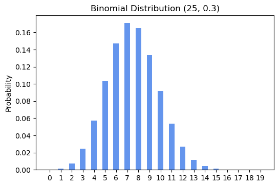

```python
def factor(n):
    ans = 1
    for i in range(1 , n + 1):
        ans = ans * i
    return ans

x = np.arange(20)
hh = stats.binom(25, 0.3)
y = hh.pmf(x)
fig_hh, ax_hh = plt.subplots()
rect_hh = ax_hh.bar(x, y, width=0.5, bottom=None, align='center', color='cornflowerblue')
plt.ylabel('Probability')
plt.title('Binomial Distribution (25, 0.3)')
plt.xticks(x)
plt.show()
```

#### a.

```python
p = 0
for i in range(11):
    p = p + np.power(0.3 , i) * np.power((1 - 0.3) , 25 - i) * factor(25) /factor(i)/factor(25 - i)

print("The probability that 10 or fewer customers chose the leading brand is ", p)
```

```
The probability that 10 or fewer customers chose the leading brand is  0.9021999888782667
```

The probability that $10$ or fewer customers chose the leading brand is $\sum_{i = 1}^{10} {\frac{25!}{i! (25 - i)!}(0.3)^i (1 - 0.3)^{25 - i}} \simeq 0.902.$

#### b.

```python
p = 0
for i in range(11, 26):
    p = p + np.power(0.3 , i) * np.power((1 - 0.3) , 25 - i) * factor(25) /factor(i)/factor(25 - i)

print("The probability that  11  or more customers chose the leading brand is", p)
```

```
The probability that  11  or more customers chose the leading brand is 0.09780001112173187
```

The probability that $11$ or more customers chose the leading brand is $\sum_{i = 11}^{25} {\frac{25!}{i! (25 - i)!}(0.3)^i (1 - 0.3)^{25 - i}} \simeq 0.098.$

#### c.

```python
p = 0
p = p + np.power(0.3 , 10) * np.power((1 - 0.3) , 25 - 10) * factor(25) /factor(10)/factor(25 - 10)
print("The probability that 10 customers chose the leading brand is", p)
```

```
The probability that 10 customers chose the leading brand is 0.09163601238321353
```

The probability that $10$ customers chose the leading brand is $\frac{25!}{10! (25 - 10)!} (0.3)^10 (1 - 0.3)^{(25 - 10)} \simeq 0.0916$

### 7.127

*All answers of this problem are round to the nearest thousandth*

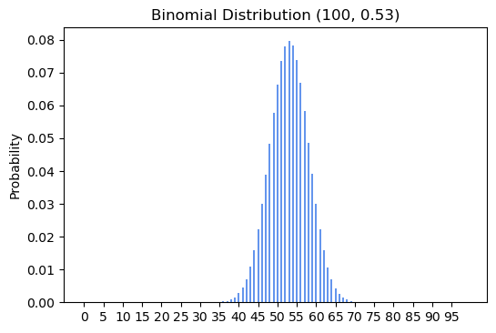

```python
x = np.arange(100)
hh = stats.binom(100, 0.53)
y = hh.pmf(x)
fig_hh, ax_hh = plt.subplots()
rect_hh = ax_hh.bar(x, y, width=0.5, bottom=None, align='center', color='cornflowerblue')
plt.ylabel('Probability')
plt.title('Binomial Distribution (100, 0.53)')
plt.xticks(np.arange(0, 100, 5), np.arange(0, 100, 5), fontsize=10)
plt.show()
```

#### a.

```python
p = 0
for i in range(51, 101):
    p = p + np.power(0.53 , i) * np.power((1 - 0.53) ,  100 - i) * factor(100) /factor(i)/factor(100 - i)

print("The probability that more than half say that Congress is doing a poor or bad job is", p)
```

```
The probability that more than half say that Congress is doing a poor or bad job is 0.6921991139282937
```

The probability that more than half say that Congress is doing a poor or bad job is $\sum_{i = 51}^{100} {\frac{100!}{i! (100 - i)!}{(0.53)^i (1 - 0.53)^{(100 - i)}}} \simeq 0.692$

#### b.

```python
p = 0
for i in range(61, 101):
    p = p + np.power(0.53 , i) * np.power((1 - 0.53) ,  100 - i) * factor(100) /factor(i)/factor(100 - i)

print("The probability that more than 60% say that Congress is doing a poor or bad job is", p)
```

```
The probability that more than 60% say that Congress is doing a poor or bad job is 0.06592297187070088
```

The probability that more than 60% say that Congress is doing a poor or bad job is $\sum_{i = 61}^{100} {\frac{100!}{i! (100 - i)!}{(0.53)^i (1 - 0.53)^{(100 - i)}}} \simeq 0.066$

#### c.

Since it's a Binomial Distribution, we can know that the expected number of American adults in the sample would say that Congress is doing a poor or bad job is $np$ while $n$ represents for the number of trials and $p$ represents the succeess rate(in this case, is that $53\%$ believed that Congress is doing a poor or bad job). Hence the expected number of American adults in the sample would say that Congress is doing a poor or bad job is $100 \times 53 \% = 53$.

Therefore, it's expected that $53$ adults out of the $100$ will say that Congress is doing a poor or bad job.

### 7.133

All the answers to this quesion are rounded off to the 6th decimal place.

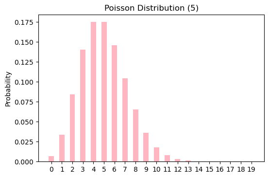

```python
x = np.arange(20)
pp = stats.poisson(5)
y = pp.pmf(x)
fig_pp, ax_pp = plt.subplots()
rect_pp = ax_pp.bar(x, y, width=0.5, bottom=None, align='center', color='lightpink')
plt.ylabel('Probability')
plt.title('Poisson Distribution (5)')
plt.xticks(x)
plt.show()
```

#### a.

```python
pp = stats.poisson(5)
print("p(mu = 5,", "x>=", 10, ")=", 1 - pp.cdf(9))
```

```
p(mu = 5, x>= 10 )= 0.03182805730620486
```

The probability that the site gets $10$ or more hits in a week is $0.031828$ after using solving it through the `poisson` functions in python.

#### b.

```python
pp = stats.poisson(10)
print("p(mu = 10,", "x>=", 20, ")=", 1 - pp.cdf(19))
```

```
p(mu = 10, x>= 20 )= 0.0034543419758568117
```

The probability that the site gets 20 or more hits in two weeks is $0.003454$ after using solving it through the poisson functions in python.

### 7.141

All the answers to this quesion are rounded off to the 6th decimal place.

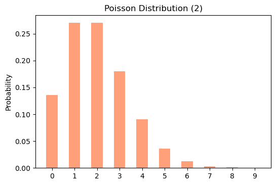

```python
x = np.arange(10)
pp = stats.poisson(2)
y = pp.pmf(x)
fig_pp, ax_pp = plt.subplots()
rect_pp = ax_pp.bar(x, y, width=0.5, bottom=None, align='center', color= 'lightsalmon')
plt.ylabel('Probability')
plt.title('Poisson Distribution (2)')
plt.xticks(x)
plt.show()
```

#### a.

```python
pp = stats.poisson(2)
print("p(mu = 2,", "x = ", 0, ")=", pp.pmf(0))
```

```
p(mu = 2, x =  0 )= 0.1353352832366127
```

The probability that a golfer loses no golf balls is $0.135335$.

#### b.

In the description, I don't know what's the meaning of "A golfer **loses 4 or more no golf balls**"; therefore, I predicted that the 'no' is accidentally typed. Hence, I answered this question with the thinking that the problem is asking "A golfer **loses 4 or more golf balls**".

```python
pp = stats.poisson(2)
print("p(mu = 2,", "x >= ", 4, ")=", 1 - pp.cdf(3))
```

```
p(mu = 2, x >=  4 )= 0.14287653950145296
```

The probability that a golfer **loses 4 or more golf balls** is $0.142877$.

#### c.

```python
pp = stats.poisson(2)
print("p(mu = 2,", "x <= ", 2, ")=", pp.cdf(2))
```

```
p(mu = 2, x <=  2 )= 0.6766764161830634
```

The probability that a golfer loses 2 or fewer golf balls is $0.676676$.